# Industry 4.0 의 중심, BigData

Data Processing Based Python @ [FB / jskim.kr](https://www.facebook.com/jskim.kr), [김진수](bigpycraft@gmail.com)

### 워드클라우드 : 이미지마스킹 - 한글 버전

#### Kkma 형태소분석기

> from konlpy.tag import Kkma
> - kkma.pos(phrase, flatten=True) : POS tagger
> - kkma.sentences(phrase) : Sentence detection. 문장 검색
> - kkma.nouns(phrase) : Noun extractor. 명사 추출기
> - kkma.morphs(phrase) : Parse phrase to morphemes. 형태소 분석 문구
> - kkma.tagset : dict  
>   {'EC': '연결 어미', 'ECD': '의존적 연결 어미', 'ECE': '대등 연결 어미', 'ECS': '보조적 연결 어미', 'EF': '종결 어미', 'EFA': <...> 체언 접두사', 'XPV': '용언 접두사', 'XR': '어근', 'XSA': '형용사 파생 접미사', 'XSN': '명사파생 접미사', 'XSV': '동사 파생 접미사'}

```python
import nltk
from konlpy.tag import Kkma
```

```python
kkma = Kkma()
```

```python
# text = '''
#     하늘아래 땅이있고 그위에 내가 있으니
#     어디인들 이 내몸 둘곳이야 없으리

#     하루해가 저문다고 울터이냐
#     그리도 내가 작더냐
#     별이지는 저 산너머
#     내 그리 쉬어가리라
#     바람아 불어라 이 내몸을 날려주려마
#     하늘아 구름아 내 몸 실어 떠나가련다

#     해가지고 달이뜨고 그안에 내가 숨쉬니
#     어디인들 이 내몸 갈 곳이야 없으리

#     작은것을 사랑하며 살 터이다
#     친구를 사랑하리라
#     말이없는 저 들녘에
#     내님을 그려보련다.

#     바람아 불어라 이내몸을 날려주려마
#     하늘아 구름아 내 몸 실어 떠나가련다
#     바람아 불어라 이 내몸을 날려주려마
#     하늘아 구름아 내 몸 실어 떠나가련다
# '''
```

```python
text = """
유시민 항소이유서 중 네크라소프의 인용구입니다.
슬픔도 노여움도 없이 살아가는 자는 조국을 사랑하고 있지 않다
"""
```

```python
kkma.sentences(text)
```

```
['유시민 항소 이유서 중 네 크라 소프의 인용구입니다.', '슬픔도 노여움도 없이 살아가는 자는 조국을 사랑하고 있지 않다']
```

```python
kkma.nouns(text)
```

```
['유',
 '유시민',
 '시민',
 '항소',
 '항소이유서',
 '이유서',
 '중',
 '소프',
 '인용구',
 '슬픔',
 '노여움',
 '자',
 '조국',
 '사랑']
```

```python
kkma.morphs(text)
```

```
['유',
 '시민',
 '항소',
 '이유서',
 '중',
 '네',
 '크',
 '라',
 '소프',
 '의',
 '인용구',
 '이',
 'ㅂ니다',
 '.',
 '슬픔',
 '도',
 '노여움',
 '도',
 '없이',
 '살아가',
 '는',
 '자',
 '는',
 '조국',
 '을',
 '사랑',
 '하',
 '고',
 '있',
 '지',
 '않',
 '다']
```

```python
kkma.pos(text)
```

```
[('유', 'NNG'),
 ('시민', 'NNG'),
 ('항소', 'NNG'),
 ('이유서', 'NNG'),
 ('중', 'NNB'),
 ('네', 'MDN'),
 ('크', 'VA'),
 ('라', 'ECD'),
 ('소프', 'NNG'),
 ('의', 'JKG'),
 ('인용구', 'NNG'),
 ('이', 'VCP'),
 ('ㅂ니다', 'EFN'),
 ('.', 'SF'),
 ('슬픔', 'NNG'),
 ('도', 'JX'),
 ('노여움', 'NNG'),
 ('도', 'JX'),
 ('없이', 'MAG'),
 ('살아가', 'VV'),
 ('는', 'ETD'),
 ('자', 'NNB'),
 ('는', 'JX'),
 ('조국', 'NNG'),
 ('을', 'JKO'),
 ('사랑', 'NNG'),
 ('하', 'XSV'),
 ('고', 'ECE'),
 ('있', 'VXV'),
 ('지', 'ECD'),
 ('않', 'VXV'),
 ('다', 'EFN')]
```

```python
kkma.pos("하이, 꼬꼬마 pos로 형태소 분석을 해보자.")
```

```
[('하이', 'NNG'),
 (',', 'SP'),
 ('꼬꼬마', 'NNG'),
 ('pos', 'OL'),
 ('로', 'JKM'),
 ('형태소', 'NNG'),
 ('분석', 'NNG'),
 ('을', 'JKO'),
 ('해보', 'VV'),
 ('자', 'ECE'),
 ('.', 'SF')]
```

```python
text = '안녕하세요? 빅데이터과정입니다. 문장에서 명사를 빼어 보십시오. 명사만~'
```

```python
kkma.nouns(text)
```

```
['안녕', '빅', '빅데이터과정', '데이터', '과정', '문장', '명사', '빼어']
```

```python
kkma.sentences(text)
```

```
['안녕하세요?', '빅 데이터 과정입니다.', '문장에서 명사를 빼어 보십시오.', '명사만~']
```

```python
kkma.pos(text)
```

```
[('안녕', 'NNG'),
 ('하', 'XSV'),
 ('세요', 'EFN'),
 ('?', 'SF'),
 ('빅', 'NNG'),
 ('데이터', 'NNG'),
 ('과정', 'NNG'),
 ('이', 'VCP'),
 ('ㅂ니다', 'EFN'),
 ('.', 'SF'),
 ('문장', 'NNG'),
 ('에서', 'JKM'),
 ('명사', 'NNG'),
 ('를', 'JKO'),
 ('빼어', 'UN'),
 ('보', 'VV'),
 ('시', 'EPH'),
 ('ㅂ시오', 'EFN'),
 ('.', 'SF'),
 ('명사', 'NNG'),
 ('만', 'JX'),
 ('~', 'SO')]
```

### 대한민국헌법 형태소분석

> from konlpy.tag import Kkma

```python
with open('wc_docu/대한민국헌법.txt') as fp:
    text = fp.read()

len(text)
```

```
20241
```

```python
text
```

```
'대한민국헌법\n[시행 1988.2.25.] [헌법 제10호, 1987.10.29., 전부개정]\n전문\n\n       유구한 역사와 전통에 빛나는 우리 대한국민은 3·1운동으로 건립된 대한민국임시정부의 법통과 불의에 항거한 4·19민주이념을 계승하고, 조국의 민주개혁과 평화적 통일의 사명에 입각하여 정의·인도와 동포애로써 민족의 단결을 공고히 하고, 모든 사회적 폐습과 불의를 타파하며, 자율과 조화를 바탕으로 자유민주적 기본질서를 더욱 확고히 하여 정치·경제·사회·문화의 모든 영역에 있어서 각인의 기회를 균등히 하고, 능력을 최…
```

```python
txt_pos = kkma.pos(text)
txt_pos
```

```
[('대한민국', 'NNG'),
 ('헌법', 'NNG'),
 ('[', 'SS'),
 ('시행', 'NNG'),
 ('1988.2', 'NR'),
 ('.', 'SF'),
 ('25', 'NR'),
 ('.', 'SF'),
 (']', 'SS'),
 ('[', 'SS'),
 ('헌법', 'NNG'),
 ('제', 'NNG'),
 ('10', 'NR'),
 ('호', 'NNM'),
 (',', 'SP'),
 ('1987.10', 'NR'),
 ('.', 'SF'),
 ('29', 'NR'),
 ('.', 'SF'),
 (',', 'SP'),
 ('전부', 'NNG'),
 ('개정', 'NNG'),
 (']', 'SS'),
 ('전문', 'NNG'),
 ('유구', 'NNG'),
 ('하', 'XSV'),
 ('ㄴ', 'ETD'),
 ('역사', 'NNG'),
 ('와', 'JC'),
 ('전통', 'NNG'),
 ('에', 'JKM'),
 ('빛나', 'VV'),
 ('는', 'ETD'),
 ('우리', 'NNM'),
 ('대하', 'VV'),
 ('ㄴ', 'ETD'),
 ('국민', 'NNG'),
 ('은', 'JX'),
 ('3', 'NR'),
 ('·', 'SP'),
```

[output cut: 946 more lines]

```
 ('③', 'SW'),
 ('체포', 'NNG'),
 ('·', 'SP'),
 ('구속', 'NNG'),
 ('·', 'SP'),
 ('압수', 'NNG'),
 ('또는', 'MAG'),
 ('수색', 'NNG'),
 ('을', 'JKO'),
 ('하', 'VV'),
 ('ㄹ', 'ETD'),
 ('때', 'NNG'),
 ('에', 'JKM'),
 ('는', 'JX'),
 ...]
```

```python
txt_nouns = kkma.nouns(text)
txt_nouns
```

```
['대한',
 '대한민국',
 '대한민국헌법',
 '민국',
 '헌법',
 '시행',
 '1988.2',
 '25',
 '제',
 '제10호',
 '10',
 '호',
 '1987.10',
 '29',
 '전부',
 '전부개정',
 '개정',
 '전문',
 '유구',
 '역사',
 '전통',
 '우리',
 '국민',
 '3',
 '1',
 '1운동',
 '운동',
 '건립',
 '대한민국임시정부',
 '임시',
 '정부',
 '법통',
 '불의',
 '항거',
 '4',
 '19',
 '19민주이념',
 '민주',
 '이념',
 '계승',
```

[output cut: 946 more lines]

```
 '득표수',
 '선거권자',
 '총수',
 '피',
 '피선거권',
 '선거일',
 '현재',
 '40세',
 '세',
 '제68조',
 '68',
 '임기만료',
 '70',
 '70일',
 ...]
```

```python
txt_morphs = kkma.morphs(text)
txt_morphs
```

```
['대한민국',
 '헌법',
 '[',
 '시행',
 '1988.2',
 '.',
 '25',
 '.',
 ']',
 '[',
 '헌법',
 '제',
 '10',
 '호',
 ',',
 '1987.10',
 '.',
 '29',
 '.',
 ',',
 '전부',
 '개정',
 ']',
 '전문',
 '유구',
 '하',
 'ㄴ',
 '역사',
 '와',
 '전통',
 '에',
 '빛나',
 '는',
 '우리',
 '대하',
 'ㄴ',
 '국민',
 '은',
 '3',
 '·',
```

[output cut: 946 more lines]

```
 '③',
 '체포',
 '·',
 '구속',
 '·',
 '압수',
 '또는',
 '수색',
 '을',
 '하',
 'ㄹ',
 '때',
 '에',
 '는',
 ...]
```

```python
txt_sentences = kkma.sentences(text)
txt_sentences
```

```
['대한민국 헌법 [ 시행 1988.2.25.] [ 헌법 제 10호, 1987.10.29., 전부 개정] 전문 유구한 역사와 전통에 빛나는 우리 대한 국민은 3·1 운동으로 건립된 대한민국 임시정부의 법통과 불의에 항거한 4·19 민주이념을 계승하고, 조국의 민주개혁과 평화적 통일의 사명에 입각하여 정의· 인도와 동포애로써 민족의 단결을 공고히 하고, 모든 사회적 폐습과 불의를 타파하며, 자율과 조화를 바탕으로 자유 민주적 기본질서를 더욱 확고히 하여 정치· 경제· 사회· 문화의 모든 영역에 있어서 각인의 기회를 균등 히 하고, 능…
 '제 1장 총 강 조문체계도 버튼 제 1조 ① 대한민국은 민주 공화국이다.',
 '② 대한민국의 주권은 국민에게 있고, 모든 권력은 국민으로부터 나온다.',
 '조문체계도 버튼 제 2조 ① 대한민국의 국민이 되는 요건은 법률로 정한다.',
 '② 국가는 법률이 정하는 바에 의하여 재외 국민을 보호할 의무를 진다.',
 '조문체계도 버튼 제 3조 대한민국의 영토는 한반도와 그 부속도 서로 한다.',
 '조문체계도 버튼 제 4조 대한민국은 통일을 지향하며, 자유 민주적 기본질서에 입각한 평화적 통일 정책을 수립하고 이를 추진한다.',
 '조문체계도 버튼 제 5조 ① 대한민국은 국제평화의 유지에 노력하고 침략적 전쟁을 부인한다.',
 '② 국 군은 국가의 안전보장과 국토 방위의 신성한 의무를 수행함을 사명으로 하며, 그 정치적 중립성은 준수된다.',
 '조문체계도 버튼 제 6조 ① 헌법에 의하여 체결· 공포된 조약과 일반적으로 승인된 국제 법규는 국내 법과 같은 효력을 가진다.',
 '② 외국인은 국제법과 조약이 정하는 바에 의하여 그 지위가 보장된다.',
 '조문체계도 버튼 제 7조 ① 공무원은 국민 전체에 대한 봉사자이며, 국민에 대하여 책임을 진다.',
 '② 공무원의 신분과 정치적 중립성은 법률이 정하는 바에 의하여 보장된다.',
 '조문체계도 버튼 제 8조 ① 정당의 설립은 자유이며, 복수 정당제는 보장된다.',
 '② 정당은 그 목적· 조직과 활동이 민주적이어야 하며, 국민의 정치적 의사형성에 참여하는데 필요한 조직을 가져야 한다.',
 '③ 정당은 법률이 정하는 바에 의하여 국가의 보호를 받으며, 국가는 법률이 정하는 바에 의하여 정당운영에 필요한 자금을 보조할 수 있다.',
 '④ 정당의 목적이나 활동이 민주적 기본질서에 위배될 때에는 정부는 헌법재판소에 그 해산을 제소할 수 있고, 정당은 헌법재판소의 심판에 의하여 해산된다.',
 '조문체계도 버튼 제 9조 국가는 전통문화의 계승· 발전과 민족문화의 창달에 노력하여야 한다.',
 '제 2 장 국민의 권리와 의무 조문체계도 버튼 제 10조 모든 국민은 인간으로서의 존엄과 가치를 가지며, 행복을 추구할 권리를 가진다.',
 '국가는 개인이 가지는 불가침의 기본적 인권을 확인하고 이를 보장할 의무를 진다.',
 '조문체계도 버튼 제 11조 ① 모든 국민은 법 앞에 평등하다.',
 '누구든지 성별· 종교 또는 사회적 신분에 의하여 정치적· 경제적· 사회적· 문화적 생활의 모든 영역에 있어서 차별을 받지 아니한다.',
 '② 사회적 특수계급의 제도는 인정되지 아니하며, 어떠한 형태로도 이를 창설할 수 없다.',
 '③ 훈장 등의 영전은 이를 받은 자에게만 효력이 있고, 어떠한 특권도 이에 따르지 아니한다.',
 '조문체계도 버튼 제 12조 ① 모든 국민은 신체의 자유를 가진다.',
 '누구든지 법률에 의하지 아니하고는 체포· 구속· 압수· 수색 또는 심문을 받지 아니하며, 법률과 적법한 절차에 의하지 아니하고는 처벌· 보안 처분 또는 강제 노역을 받지 아니한다.',
 '② 모든 국민은 고문을 받지 아니하며, 형사상 자기에게 불리한 진술을 강요당하지 아니한다.',
 '③ 체포· 구속· 압수 또는 수색을 할 때에는 적법한 절차에 따라 검사의 신청에 의하여 법관이 발부한 영장을 제시하여야 한다.',
 '다만, 현행 범인인 경우와 장기 3년 이상의 형에 해당하는 죄를 범하고 도피 또는 증거 인멸의 염려가 있을 때에는 사후에 영장을 청구할 수 있다.',
 '④ 누구든지 체포 또는 구속을 당한 때에는 즉시 변호인의 조력을 받을 권리를 가진다.',
 '다만, 형사 피고인이 스스로 변호인을 구할 수 없을 때에는 법률이 정하는 바에 의하여 국가가 변호인을 붙인다.',
 '⑤ 누구든지 체포 또는 구속의 이유와 변호인의 조력을 받을 권리가 있음을 고지 받지 아니하고는 체포 또는 구속을 당하지 아니한다.',
 '체포 또는 구속을 당한 자의 가족 등 법률이 정하는 자에게는 그 이유와 일시· 장소가 지체 없이 통지되어야 한다.',
 '⑥ 누구든지 체포 또는 구속을 당한 때에는 적부의 심사를 법원에 청구할 권리를 가진다.',
 '⑦ 피고인의 자백이 고문· 폭행· 협박· 구속의 부당한 장기화 또는 기망 기타의 방법에 의하여 자의로 진술된 것이 아니라고 인정될 때 또는 정식재판에 있어서 피고인의 자백이 그에게 불리한 유일한 증거일 때에는 이를 유죄의 증거로 삼거나 이를 이유로 처벌할 수 없다.',
 '조문체계도 버튼 제 13조 ① 모든 국민은 행위시의 법률에 의하여 범죄를 구성하지 아니하는 행위로 소 추되지 아니하며, 동일한 범죄에 대하여 거듭 처벌 받지 아니한다.',
 '② 모든 국민은 소급 입법에 의하여 참정권의 제한을 받거나 재산권을 박탈당하지 아니한다.',
 '③ 모든 국민은 자기의 행위가 아닌 친족의 행위로 인하여 불이익한 처우를 받지 아니한다.',
 '조문체계도 버튼 제 14조 모든 국민은 거주· 이전의 자유를 가진다.',
 '조문체계도 버튼 제 15조 모든 국민은 직업선택의 자유를 가진다.',
```

[output cut: 277 more lines]

```
 '조문체계도 버튼 제 130조 ① 국회는 헌법 개정안이 공고된 날로부터 60일 이내에 의결하여야 하며, 국회의 의결은 재적 의원 3분의 2 이상의 찬성을 얻어야 한다.',
 '② 헌법 개정안은 국회가 의결한 후 30일 이내에 국민투표에 붙여 국회의원 선거권자 과반수의 투표와 투표자 과반수의 찬성을 얻어야 한다.',
 '③ 헌법 개정안이 제 2 항의 찬성을 얻은 때에는 헌법 개정은 확정되며, 대통령은 즉시 이를 공포하여야 한다.',
 '펼침 부 칙 < 헌법 제 10호, 1987.10.29.> 부칙 보기 제 1조 이 헌법은 1988년 2월 25일부터 시행한다.',
 '다만, 이 헌법을 시행하기 위하여 필요한 법률의 제정· 개정과 이 헌법에 의한 대통령 및 국회의원의 선거 기타 이 헌법 시행에 관한 준비는 이 헌법 시행 전에 할 수 있다.',
 '제 2조 ① 이 헌법에 의한 최초의 대통령 선거는 이 헌법 시행 일 40일 전까지 실시한다.',
 '② 이 헌법에 의한 최초의 대통령의 임기는 이 헌법 시행 일로부터 개시한다.',
 '제 3조 ① 이 헌법에 의한 최초의 국회의원선거는 이 헌법 공포 일로부터 6월 이내에 실시하며, 이 헌법에 의하여 선출된 최초의 국회의원의 임기는 국회의원선거 후 이 헌법에 의한 국회의 최초의 집회 일로부터 개시한다.',
 '② 이 헌법 공포 당시의 국회의원의 임기는 제 1 항에 의한 국회의 최초의 집회 일 전일까지로 한다.',
 '제 4조 ① 이 헌법 시행 당시의 공무원과 정부가 임명한 기업체의 임원은 이 헌법에 의하여 임명된 것으로 본다.',
 '다만, 이 헌법에 의하여 선임방법이나 임명권 자가 변경된 공무원과 대법원장 및 감사원장은 이 헌법에 의하여 후임자가 선임될 때까지 그 직무를 행하며, 이 경우 전임자인 공무원의 임기는 후임자가 선임되는 전일까지로 한다.',
 '② 이 헌법 시행 당시의 대법원장과 대법원판사가 아닌 법관은 제 1 항 단서의 규정에 불구하고 이 헌법에 의하여 임명된 것으로 본다.',
 '③ 이 헌법 중 공무원의 임기 또는 중임제한에 관한 규정은 이 헌법에 의하여 그 공무원이 최초로 선출 또는 임명된 때로부터 적용한다.',
 '제 5조 이 헌법 시행 당시의 법령과 조약은 이 헌법에 위배되지 아니하는 한 그 효력을 지속한다.',
 '제 6조 이 헌법 시행 당시에 이 헌법에 의하여 새로 설치될 기관의 권한에 속하는 직무를 행하고 있는 기관은 이 헌법에 의하여 새로운 기관이 설치될 때까지 존속하며 그 직무를 행한다.']
```

```python
result = """
대한민국헌법 형태소분석 결과입니다.
    - POS태그  \t: {}개
    - 형태소   \t: {}개
    - 명사갯수 \t: {}개
    - 문장갯수 \t: {}개
 """.format(len(txt_pos), len(txt_morphs), len(txt_nouns), len(txt_sentences))
print(result)
```

```
대한민국헌법 형태소분석 결과입니다.
    - POS태그  	: 10482개
    - 형태소   	: 10482개
    - 명사갯수 	: 1584개
    - 문장갯수 	: 332개
```

### KoNLPy.tag : Twitter, 트위트

#### Twitter 형태소분석기

> from konlpy.tag import Twitter
> - twitter.jki(*args, **kwargs)
> - twitter.pos(phrase, norm=False, stem=False) : POS tagger
> - twitter.phrases(phrase) : Phrase extractor. 구문 추출기
> - twitter.nouns(phrase) : Noun extractor. 명사 추출기
> - twitter.morphs(phrase, norm=False, stem=False) : Parse phrase to morphemes. 형태소 분석 문구
> - twitter.tagset : dict  
>   {'Adjective': '형용사', 'Adverb': '부사', 'Alpha': '알파벳', 'Conjunction': '접속사', 'Determiner': '관형사', ' <...> 'Punctuation': '구두점', 'ScreenName': '트위터 아이디', 'Suffix': '접미사', 'Unknown': '미등록어', 'Verb': '동사'}

```python
# 대한민국 헌법 내장 데이터
from konlpy.corpus import kolaw
```

```python
from konlpy.tag import Twitter
```

```python
twitter = Twitter()
```

```python
constitution = kolaw.open('constitution.txt').read()
constitution[:1000]
```

```
'대한민국헌법\n\n유구한 역사와 전통에 빛나는 우리 대한국민은 3·1운동으로 건립된 대한민국임시정부의 법통과 불의에 항거한 4·19민주이념을 계승하고, 조국의 민주개혁과 평화적 통일의 사명에 입각하여 정의·인도와 동포애로써 민족의 단결을 공고히 하고, 모든 사회적 폐습과 불의를 타파하며, 자율과 조화를 바탕으로 자유민주적 기본질서를 더욱 확고히 하여 정치·경제·사회·문화의 모든 영역에 있어서 각인의 기회를 균등히 하고, 능력을 최고도로 발휘하게 하며, 자유와 권리에 따르는 책임과 의무를 완수하게 하여, 안으로는 국민생활의 균등한 …
```

```python
# 트위터 형태소 분석 후 명사만 추출
constitution_nouns = twitter.nouns(constitution)
len(constitution_nouns)
```

```
3779
```

```python
constitution_nouns[:10]
```

```
['대한민국', '헌법', '유구', '역사', '전통', '우리', '대한', '국민', '운동', '건립']
```

```python
one_words = []
tow_words = []
etc_words = []
for noun in constitution_nouns:
    if len(noun) == 1:
        one_words.append(noun)
    elif len(noun) == 2:
        tow_words.append(noun)
    else:
        etc_words.append(noun)

len(one_words), len(tow_words), len(etc_words)
```

```
(844, 2451, 484)
```

```python
one_words = list(set(one_words))
tow_words = list(set(tow_words))
etc_words = list(set(etc_words))

len(one_words), len(tow_words), len(etc_words)
```

```
(73, 694, 147)
```

```python
for word in one_words:
    print(word, end='\t')
```

```
외	둘	겸	도	전	해	차	물	새	항	위	응	일	및	내	임	음	소	표	호	함	장	세	계	월	앞	안	제	직	를	와	그	애	범	등	멸	중	못	밖	이	관	개	진	때	변	조	자	시	후	령	침	법	것	예	죄	수	형	과	체	나	인	분	비	농	년	명	발	각	입	적	회	절	바
```

```python
stop_words = []
# stop_words = ['제', '월', '일','조','수','때','그','이','바','및','안']
stop_words.extend(one_words)
len(stop_words)
```

```
73
```

```python
# stop_words.index('법')
# stop_words.remove('법')
# len(stop_words)
```

```python
# stop_words 빼기
constitution_nouns = [word for word in constitution_nouns if word not in stop_words]
len(constitution_nouns)
```

```
2935
```

```python
constitution_nouns[:10]
```

```
['대한민국', '헌법', '유구', '역사', '전통', '우리', '대한', '국민', '운동', '건립']
```

```python
constitution  = nltk.Text(constitution_nouns, name='헌법')
type(constitution), len(constitution)
```

```
(nltk.text.Text, 2935)
```

```python
# 상위 30개 수
constitution.vocab().most_common(30)
```

```
[('법률', 127),
 ('대통령', 83),
 ('국가', 73),
 ('국회', 68),
 ('국민', 61),
 ('헌법', 53),
 ('모든', 37),
 ('기타', 26),
 ('사항', 23),
 ('권리', 21),
 ('의원', 21),
 ('경제', 20),
 ('정부', 20),
 ('선거', 20),
 ('임명', 20),
 ('자유', 19),
 ('직무', 19),
 ('국무총리', 19),
 ('의무', 18),
 ('조직', 18),
 ('국회의원', 18),
 ('임기', 18),
 ('의결', 17),
 ('공무원', 17),
 ('정당', 17),
 ('경우', 17),
 ('이상', 17),
 ('국무위원', 17),
 ('대법원', 17),
 ('범위', 16)]
```

### 워드클라우드 한글폰트 설정

```python
from matplotlib import font_manager, rc

font_name = font_manager.FontProperties(fname="C:/Windows/Fonts/malgun.ttf").get_name()
rc('font', family=font_name)
```

```python
# nltk패키지를 통해 konlpy에서 뽑은 명사들 상위 500개 추출
data = constitution.vocab().most_common(500)
len(data)
```

```
500
```

```python
data[:10]
```

```
[('법률', 127),
 ('대통령', 83),
 ('국가', 73),
 ('국회', 68),
 ('국민', 61),
 ('헌법', 53),
 ('모든', 37),
 ('기타', 26),
 ('사항', 23),
 ('권리', 21)]
```

```python
# data를 딕셔너리 형태로 변환
dict_data = dict(data)
len(dict_data)
```

```
500
```

```python
%matplotlib inline
import matplotlib.pyplot as plt
from wordcloud import WordCloud
```

```python
wordcloud = WordCloud(font_path='C:/Windows/Fonts/malgun.ttf',
                      background_color='white'
                     ,relative_scaling =0.2).generate_from_frequencies(dict_data)
```

```
(-0.5, 399.5, 199.5, -0.5)
```

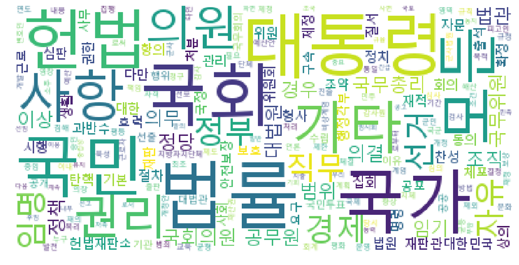

```python
plt.figure(figsize=(20,12))
plt.imshow(wordcloud)
plt.axis('off')
```

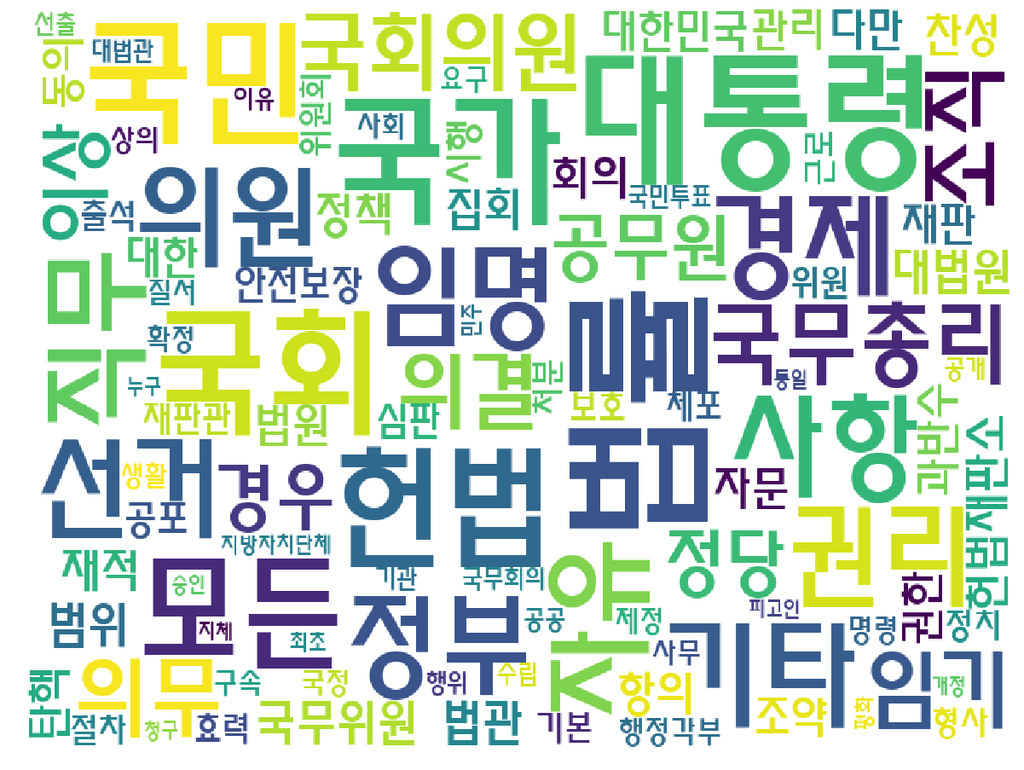

```python
params = {
    "width"            : 800,
    "height"           : 600,
    "min_font_size"    : 2**3,
    "max_font_size"    : 2**7,
    "max_words"        : 100,
    "relative_scaling" : 0.2,
    # "font_path"        : 'C:/Windows/Fonts/malgun.ttf',
    "font_path"        : 'C:/Windows/Fonts/HMFMMUEX.TTC',
    "background_color" : 'white',
}

wordcolud = WordCloud(**params)
# wordcolud = wordcolud.generate(text)
wordcolud = wordcolud.generate_from_frequencies(dict_data)

save_img = 'wc_result/constitution_1.png'

plt.figure(figsize=(24,16))
plt.imshow(wordcolud)
plt.axis('off')
plt.savefig(save_img)
```

### 사진+워드클라우드

```python
import numpy as np
from PIL import Image
from wordcloud import ImageColorGenerator
```

```python
# 이미지파일 numpy로 읽기
shape_img = np.array(Image.open('images/mask_ahn_palm.jpg'))
cloud_img = ImageColorGenerator(shape_img)
```

```
(-0.5, 387.5, 458.5, -0.5)
```

[figure not shown]

```python
plt.figure(figsize=(12,12))
plt.imshow(shape_img)
plt.axis('off')
```

```python
wordcloud = WordCloud(font_path='C:/Windows/Fonts/malgun.ttf',
                     relative_scaling = 0.2,
                     mask = shape_img,
                     background_color = 'white',
                     min_font_size=1, max_font_size=40).generate_from_frequencies(dict_data)
```

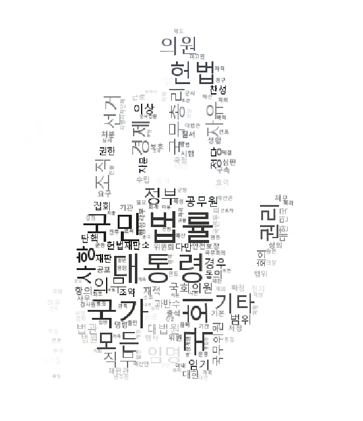

```python
save_img = 'wc_result/constitution_2.png'
plt.figure(figsize=(12, 12))
plt.imshow(wordcloud.recolor(color_func=cloud_img))
plt.axis('off')
plt.savefig(save_img)
```

```python
shape_img = np.array(Image.open('images/mask_ahn_palm.jpg'))
shape_img
```

[output not shown]

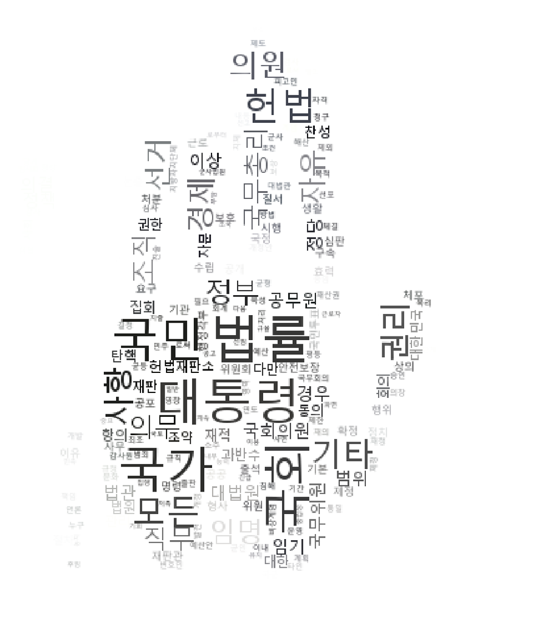

```python
shape_img = np.array(Image.open('images/mask_ahn_palm.jpg'))
cloud_img = ImageColorGenerator(shape_img)

params = {
    "width"            : 300,
    "height"           : 400,
    "max_words"        : 100,
    "relative_scaling" : 0.2,
    "background_color" : 'white',
    "font_path"        : 'C:/Windows/Fonts/malgun.ttf',
    "mask"             :  shape_img,
}

wordcolud = WordCloud(**params)
# wordcolud = wordcolud.generate(text)
wordcolud = wordcolud.generate_from_frequencies(dict_data)

save_img = 'wc_result/constitution_3.png'
plt.figure(figsize=(20,20))
plt.imshow(wordcloud.recolor(color_func=cloud_img))
plt.axis('off')
plt.savefig(save_img)
```

### 워드클라우드 실습

> - KoNLPy를 활용해서 워드클라우드 직접 작성해보기~^^

```python
import nltk
from konlpy.tag import Kkma
```

```python
kkma = Kkma()
```

```python
# text = open('./wc_docu/pyhthon_kakao_the_love.txt', encoding = 'UTF-8').read()
with open('./wc_docu/pyhthon_kakao_the_love.txt', encoding = 'UTF-8') as fp:
    text = fp.read()
```

```python
kkma.pos(text)
```

```
[('한', 'MDN'),
 ('경', 'NNG'),
 ('-', 'SW'),
 ('파이', 'NNG'),
 ('썰', 'VV'),
 ('ㄴ', 'ETD'),
 ('님', 'NNG'),
 ('과', 'JKM'),
 ('카카오', 'NNG'),
 ('톡', 'MAG'),
 ('대화', 'NNG'),
 ('저장', 'NNG'),
 ('하', 'XSV'),
 ('ㄴ', 'ETD'),
 ('날짜', 'NNG'),
 (':', 'SP'),
 ('2018-01', 'OL'),
 ('-11', 'NR'),
 ('16', 'NR'),
 (':', 'SP'),
 ('46', 'NR'),
 (':', 'SP'),
 ('16', 'NR'),
 ('--', 'EMO'),
 ('--', 'EMO'),
 ('--', 'EMO'),
 ('--', 'EMO'),
 ('--', 'EMO'),
 ('--', 'EMO'),
 ('--', 'EMO'),
 ('-', 'SW'),
 ('2018', 'NR'),
 ('년', 'NNM'),
 ('1', 'NR'),
 ('월', 'NNM'),
 ('2', 'NR'),
 ('일', 'NNM'),
 ('화요일', 'NNG'),
 ('--', 'EMO'),
 ('--', 'EMO'),
```

[output cut: 946 more lines]

```
 ('붐', 'NNG'),
 ('-', 'SW'),
 ('상상', 'NNG'),
 ('더하기', 'NNG'),
 ('[', 'SS'),
 ('만두', 'NNG'),
 (']', 'SS'),
 ('[', 'SS'),
 ('오전', 'NNG'),
 ('9', 'NR'),
 (':', 'SP'),
 ('45', 'NR'),
 (']', 'SS'),
 ('국민', 'NNG'),
 ...]
```

```python
kkma.nouns(text)
```

```
['경',
 '파이',
 '님',
 '카카오',
 '대화',
 '저장',
 '날짜',
 '-11',
 '16',
 '46',
 '2018',
 '2018년',
 '년',
 '1',
 '1월',
 '월',
 '2',
 '2일',
 '일',
 '화요일',
 '백두',
 '현은',
 '현은별',
 '별',
 '다섯',
 '다섯개',
 '개',
 '백두현님',
 '현',
 '님',
 '한강가즈아님',
 '만두',
 '익명',
 '박',
 '박성은',
 '성은',
 '정일',
 '정일균',
 '균',
 '김',
```

[output cut: 397 more lines]

```
 '사랑',
 '19',
 '20',
 '점심',
 '야곱',
 '포장',
 '11일',
 '512.54',
 '지도',
 '93.41',
 '2.67',
 '황희',
 '황희정',
 '72',
 '-83165012']
```

```python
kakao_nouns = kkma.nouns(text)
stop_words  = ['오후','오전','?','[', ']','(이모티콘)','님']
kakao_nouns = [ word for word in kakao_nouns if word not in stop_words]
kakao_nouns
```

```
['경',
 '파이',
 '카카오',
 '대화',
 '저장',
 '날짜',
 '-11',
 '16',
 '46',
 '2018',
 '2018년',
 '년',
 '1',
 '1월',
 '월',
 '2',
 '2일',
 '일',
 '화요일',
 '백두',
 '현은',
 '현은별',
 '별',
 '다섯',
 '다섯개',
 '개',
 '백두현님',
 '현',
 '한강가즈아님',
 '만두',
 '익명',
 '박',
 '박성은',
 '성은',
 '정일',
 '정일균',
 '균',
 '김',
 '김정갑',
 '정갑',
```

[output cut: 393 more lines]

```
 '사랑',
 '19',
 '20',
 '점심',
 '야곱',
 '포장',
 '11일',
 '512.54',
 '지도',
 '93.41',
 '2.67',
 '황희',
 '황희정',
 '72',
 '-83165012']
```

```python
# from wordcloud import WordCloud
import wordcloud
import matplotlib.pyplot as plt
```

```python
katalk  = nltk.Text(kakao_nouns)
data = katalk.vocab().most_common(400)
dict_data = dict(data)
```

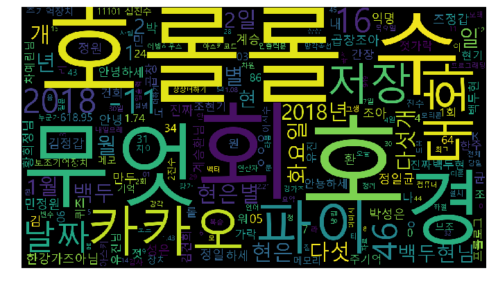

```python
wc_gen = wordcloud.WordCloud(font_path='C:/Windows/Fonts/malgun.ttf',
                             relative_scaling =0.2, width=1600, height=900
                            ).generate_from_frequencies(dict_data)
plt.figure(figsize=(12,12))
plt.imshow(wc_gen)
plt.axis('off')
plt.savefig('wc_result/katalk_love.jpg')
```

[figure not shown]

```python
wc_gen = wordcloud.WordCloud(font_path='C:/Windows/Fonts/malgun.ttf',
                             relative_scaling =0.5, width=2000, height=2000
                            ).generate_from_frequencies(dict_data)
plt.figure(figsize=(20,20))
plt.imshow(wc_gen)
plt.axis('off')
plt.savefig('wc_result/katalk_love.jpg')
```

```python
% matplotlib inline

import matplotlib.pyplot as plt
import numpy as np

from PIL import Image
from wordcloud import WordCloud
from wordcloud import ImageColorGenerator
```

```
(-0.5, 766.5, 719.5, -0.5)
```

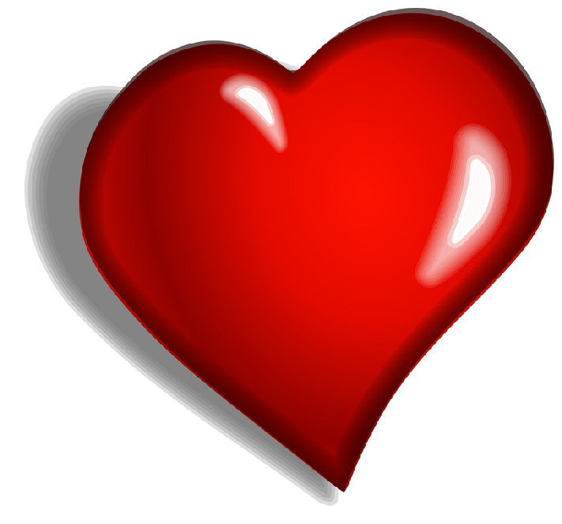

```python
mask_heart  = np.array(Image.open('images/heart.jpg'))
image_color = ImageColorGenerator(mask_heart)
plt.figure(figsize=(12,12))
plt.imshow(mask_heart)
plt.axis('off')
```

```python
wordcloud = WordCloud(font_path='C:/Windows/Fonts/malgun.ttf',
                        relative_scaling = 0.2,
                        mask = mask_heart,
                        background_color = 'white',
                        min_font_size=1,
                        max_font_size=15,
                        width=1600,
                        height=900).generate_from_frequencies(dict_data)
```

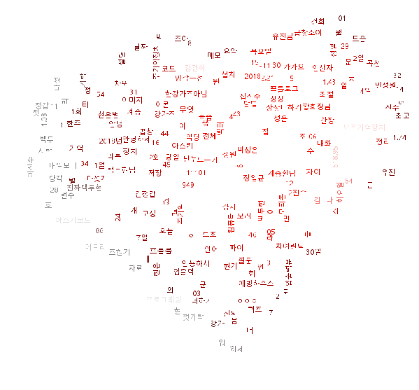

```python
plt.figure(figsize=(10,10))
plt.imshow(wordcloud.recolor(color_func=image_color))
plt.axis('off')
plt.savefig('wc_result/katalk_heart_1.png')
```

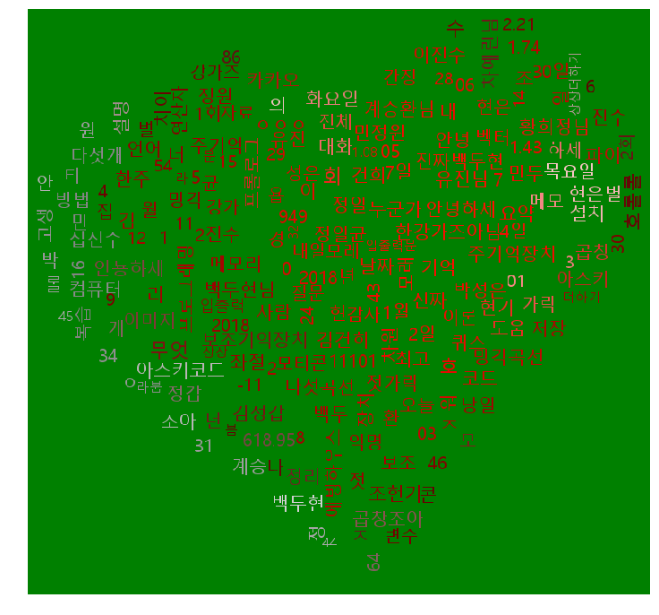

```python
params = {
    "font_path"         :'C:/Windows/Fonts/malgun.ttf',
    "relative_scaling"  : 0.2,
    "mask"              : mask_heart,
    "background_color"  : 'green',
    "max_words"         : 200,
    "min_font_size"     : 6,
    "max_font_size"     : 24,
    "width"             : 1200,
    "height"            : 900,
}

wordcloud = WordCloud(**params).generate_from_frequencies(dict_data)

plt.figure(figsize=(18,12))
plt.imshow(wordcloud.recolor(color_func=image_color))
plt.axis('off')
plt.savefig('wc_result/katalk_heart_2.png')
```

The BigpyCraft find the information to design valuable society with Technology & Craft.

< The End >